# Approaches based on a proportional cause-specific hazard specification

Karla Monterrubio-Gómez, Nathan Constantine-Cooke, and Catalina Vallejos

2022-11-16

# Data

In order to demonstrate methods using a proportional cause-specific hazard specification, we employ publicly available data.

The dataset used here corresponds to the Hodgkin’s disease (HD) study described in Pintilie, 2006. The dataset comprises 865 patients diagnosed with early stage (I or II) HD, and which were treated either with radiation (RT) or with radiation and chemotherapy (CMT).

The recorded data includes:

- age: Age (years)
- sex: Sex, F=female and M=Male.
- trtgiven: Treatment given, RT=Radiation, CMT=Chemotherapy and radiation
- medwidsi: Size of mediastinum involvement, N=No, S=Small, L=Large
- extranod: Extranodal disease, Y=Extranodal disease, N= Nodal disease
- clinstg: Clinical stage, 1=Stage I, 2=Stage II
- time: time to failure (years) calculated from the date of diagnosis
- status: 0=censoring, 1=relapse and 2=death.

We now load and display the structure of the HD dataset:

```r
require(readr)
hd <- data.frame(read_csv("../Data/HD/hd.csv",
                          col_types = cols(X1 = col_skip())))
str(hd)
```

```
#> 'data.frame':    865 obs. of  9 variables:
#>  $ ...1    : num  1 2 3 4 5 6 7 8 9 10 ...
#>  $ age     : num  64 63 17 63 21 37 41 35 27 32 ...
#>  $ sex     : chr  "F" "M" "M" "M" ...
#>  $ trtgiven: chr  "RT" "RT" "RT" "RT" ...
#>  $ medwidsi: chr  "N" "N" "N" "N" ...
#>  $ extranod: chr  "N" "N" "N" "N" ...
#>  $ clinstg : num  1 1 2 2 2 1 2 2 2 2 ...
#>  $ time    : num  3.1 15.9 0.9 13.1 35.9 1.1 2.5 0.003 4.1 28.1 ...
#>  $ status  : num  2 2 1 2 0 1 1 1 1 0 ...
```

To procede with the analysis, it is important to change the data type of sex, trtgiven, medwidsi, and extranod from `character` to `factor`. Similarly, we convert clinstg from `numeric` to `factor`.

```r
  hd$sex      <- as.factor(hd$sex)
  hd$trtgiven <- as.factor(hd$trtgiven)
  hd$medwidsi <- as.factor(hd$medwidsi)
  hd$extranod <- as.factor(hd$extranod)
  hd$clinstg  <- as.factor(hd$clinstg)
```

Now, we explore the number of events for each event type:

```r
require(pander)
pander::pander(table(hd$status))
```

| 0 | 1 | 2 |
| --- | --- | --- |
| 439 | 291 | 135 |

Thus, we have 439 censored patients, 291 with relapse and 135 who died. From now on, we assume that the event of interest is relapse, i.e. `status=1`.

In order to create a test set, we use stratified sampling to partition our data in 80% for train and 20% for test.

```r
require(splitstackshape)
set.seed(2022)
split_data <- stratified(hd, c("status"), 0.8, bothSets = TRUE)
hd_train   <- as.data.frame(split_data$SAMP1[,-1])
hd_test    <- as.data.frame(split_data$SAMP2[,-1])
```

Now, we explore the number of observations per status in both train and test set:

```r
pander::pander(table(hd_train$status))
```

| 0 | 1 | 2 |
| --- | --- | --- |
| 351 | 233 | 108 |

```r
pander::pander(table(hd_test$status))
```

| 0 | 1 | 2 |
| --- | --- | --- |
| 88 | 58 | 27 |

# Cause-specific Cox Proportional-Hazards

There are several R packages that one can employ to fit a cause-specific hazard regression model. For this purpose, separate Cox proportional hazards models are fitted for each event type, treating other events as censored observations. In this section, we explore how we can perform this task with different R packages. We discuss its similarities and differences: highlighting important aspects to consider in each case.

## The `survival` package

The model can be fit with the `coxph()` function in the `survival` package. In order to do so, one should first create a survival time object with the `Surv()` function. This object will be the response variable in our regression model. For illustration purposes, we only fit the cause-specific model associated to events of type 1. To do this, in the code below, we have set `status==1` in the second argument of `Surv()` to indicate that we are interested in event type 1. This setting will treat the other status values as censored observations. The cause-specific model for the second event type can be fitted using `status==2`.

```r
require(survival)
csh_survival <- coxph(Surv(time, status == 1) ~ age +
                        sex +
                        trtgiven +
                        medwidsi +
                        extranod +
                        clinstg,
                       data = hd_train,
                       x = TRUE,         # needed for predictions
                       # this is the default, one can also use Breslow
                       ties = "efron")
summary(csh_survival)
```

```
#> Call:
#> coxph(formula = Surv(time, status == 1) ~ age + sex + trtgiven +
#>     medwidsi + extranod + clinstg, data = hd_train, ties = "efron",
#>     x = TRUE)
#>
#>   n= 692, number of events= 233
#>
#>                 coef exp(coef)  se(coef)      z Pr(>|z|)
#> age         0.015879  1.016006  0.004249  3.738 0.000186 ***
#> sexM        0.087491  1.091432  0.134759  0.649 0.516182
#> trtgivenRT  0.713903  2.041946  0.194581  3.669 0.000244 ***
#> medwidsiN  -0.044301  0.956666  0.256368 -0.173 0.862807
#> medwidsiS  -0.402680  0.668526  0.253404 -1.589 0.112041
#> extranodY   0.326442  1.386027  0.239225  1.365 0.172384
#> clinstg2    0.371257  1.449556  0.156389  2.374 0.017600 *
#> ---
#> Signif. codes:  0 '***' 0.001 '**' 0.01 '*' 0.05 '.' 0.1 ' ' 1
#>
#>            exp(coef) exp(-coef) lower .95 upper .95
#> age           1.0160     0.9842    1.0076     1.025
#> sexM          1.0914     0.9162    0.8381     1.421
#> trtgivenRT    2.0419     0.4897    1.3945     2.990
#> medwidsiN     0.9567     1.0453    0.5788     1.581
#> medwidsiS     0.6685     1.4958    0.4068     1.099
#> extranodY     1.3860     0.7215    0.8672     2.215
#> clinstg2      1.4496     0.6899    1.0669     1.969
#>
#> Concordance= 0.61  (se = 0.02 )
#> Likelihood ratio test= 37.91  on 7 df,   p=3e-06
#> Wald test            = 38.21  on 7 df,   p=3e-06
#> Score (logrank) test = 38.95  on 7 df,   p=2e-06
```

The above output summarises the fitted model. First, it shows that out of the 692 patients, 233 experienced the event of interest (relapse). Second, it shows the coefficients and hazard ratios (`exp(coef)`) for each covariate, along with a significance test. The results suggest that age, treatment, and clinical stage are significantly associated with the hazard of relapse. For instance, being in clinical stage 2 increases the cause-specific hazard (rate) of relapse by 44.96% when compared to a patient in stage 1. It is important to emphasise that one should be cautious when interpreting these covariate effects as this modelling strategy only permits to do inference of the effects on the hazard but not on the prognosis or survival (see more details in Austin, Lee, and Fine (2016)). Finally, the output also reports model fitness statistics. The concordance index, which summaries the in-sample discriminative ability of the model (a value close to 1 is preferred), and three tests to check if (overall) the model is significant.

Note that naively estimating survival/risk probabilities from this model, will result in overestimation of the survival function, as competing risks are not taken into account. See the riskRegression section for a valid approach.

## The `rms` package

Another package that permits to fit the model is `rms`. This package provides useful functions for model validation, and plotting which are well documented in Harrell (2017).

Before fitting the model, it is important to compute summary statistics of the covariates that will be employed. Such statistics will be used when plotting or doing predictions. These summary statistics are computed using `datadist()` function.

As in the previous section, we only fit the cause specific model for the first event type. The code for the model associated to the second event type is analogous, using `status == 2` in the `Surv()` call.

```r
require(rms)

units(hd$time) <- "years"
dd <- datadist(hd)
options(datadistc = "dd")

csh_rms <- cph(Surv(time, status == 1) ~ age +
                                        sex +
                                        trtgiven +
                                        medwidsi +
                                        extranod +
                                        clinstg,
                data = hd_train,
                x = TRUE,
                y = TRUE,
                surv = TRUE,
                method = "efron")  # default is efron, one can also use breslow

print(csh_rms)
```

```
#> Cox Proportional Hazards Model
#>
#>  cph(formula = Surv(time, status == 1) ~ age + sex + trtgiven +
#>      medwidsi + extranod + clinstg, data = hd_train, method = "efron",
#>      x = TRUE, y = TRUE, surv = TRUE)
#>
#>                         Model Tests    Discrimination
#>                                               Indexes
#>  Obs       692    LR chi2     37.91    R2       0.054
#>  Events    233    d.f.            7    R2(7,692)0.044
#>  Center 1.2434    Pr(> chi2) 0.0000    R2(7,233)0.124
#>                   Score chi2  38.95    Dxy      0.219
#>                   Pr(> chi2) 0.0000
#>
#>              Coef    S.E.   Wald Z Pr(>|Z|)
#>  age          0.0159 0.0042  3.74  0.0002
#>  sex=M        0.0875 0.1348  0.65  0.5162
#>  trtgiven=RT  0.7139 0.1946  3.67  0.0002
#>  medwidsi=N  -0.0443 0.2564 -0.17  0.8628
#>  medwidsi=S  -0.4027 0.2534 -1.59  0.1120
#>  extranod=Y   0.3264 0.2392  1.36  0.1724
#>  clinstg=2    0.3713 0.1564  2.37  0.0176
#>
```

In this case, printing the fitted model, gives a slightly different output. First, the output includes several discrimination indices. Note that, the concordance index can be recovered using the `Dxy` index. Moreover, note that these metrics ignore the presence of competing event types.

`summary.rms()` is of more utility to compute hazard ratios. For continuous covariates, the HR are computed with respect to the lower and upper quartiles. For instance, from the output below we can infer that a 20-year increase in age (going from 23 to 43), increases the cause-specific hazard of relapse by 37.38% . This is in contrast to the coefficients obtained by `print()`, which in this case corresponds to `exp(coef)`=1.02 and whose interpretation refers to the effect on the hazard by 1-year increase.

```r
summary(csh_rms)
```

```
#>              Effects              Response : Surv(time, status == 1)
#>
#>  Factor            Low High Diff. Effect    S.E.     Lower 0.95 Upper 0.95
#>  age               23  43   20     0.317580 0.084972  0.15104    0.484130
#>   Hazard Ratio     23  43   20     1.373800       NA  1.16300    1.622800
#>  sex - F:M          2   1   NA    -0.087491 0.134760 -0.35161    0.176630
#>   Hazard Ratio      2   1   NA     0.916230       NA  0.70355    1.193200
#>  trtgiven - CMT:RT  2   1   NA    -0.713900 0.194580 -1.09530   -0.332530
#>   Hazard Ratio      2   1   NA     0.489730       NA  0.33445    0.717110
#>  medwidsi - L:N     2   1   NA     0.044301 0.256370 -0.45817    0.546770
#>   Hazard Ratio      2   1   NA     1.045300       NA  0.63244    1.727700
#>  medwidsi - S:N     2   3   NA    -0.358380 0.171210 -0.69395   -0.022805
#>   Hazard Ratio      2   3   NA     0.698810       NA  0.49960    0.977450
#>  extranod - Y:N     1   2   NA     0.326440 0.239220 -0.14243    0.795310
#>   Hazard Ratio      1   2   NA     1.386000       NA  0.86725    2.215100
#>  clinstg - 1:2      2   1   NA    -0.371260 0.156390 -0.67777   -0.064740
#>   Hazard Ratio      2   1   NA     0.689870       NA  0.50775    0.937310
```

Furthermore, one can manually define ranges in which we want to compute HR; for instance going from 30-40 years, i.e. a 10-year increase will result in a increase in the cause-specific hazard of 17.21%, as shown below. Similarly, for discrete covariates, one can define the reference level with respect to which the HR are computed; for example, below we have changed the reference level for sex.

```r
summary(csh_rms, age = c(30, 40), sex = "F")
```

```
#>              Effects              Response : Surv(time, status == 1)
#>
#>  Factor            Low High Diff. Effect    S.E.     Lower 0.95 Upper 0.95
#>  age               30  40   10     0.158790 0.042486  0.075521   0.242060
#>   Hazard Ratio     30  40   10     1.172100       NA  1.078400   1.273900
#>  sex - M:F          1   2   NA     0.087491 0.134760 -0.176630   0.351610
#>   Hazard Ratio      1   2   NA     1.091400       NA  0.838090   1.421400
#>  trtgiven - CMT:RT  2   1   NA    -0.713900 0.194580 -1.095300  -0.332530
#>   Hazard Ratio      2   1   NA     0.489730       NA  0.334450   0.717110
#>  medwidsi - L:N     2   1   NA     0.044301 0.256370 -0.458170   0.546770
#>   Hazard Ratio      2   1   NA     1.045300       NA  0.632440   1.727700
#>  medwidsi - S:N     2   3   NA    -0.358380 0.171210 -0.693950  -0.022805
#>   Hazard Ratio      2   3   NA     0.698810       NA  0.499600   0.977450
#>  extranod - Y:N     1   2   NA     0.326440 0.239220 -0.142430   0.795310
#>   Hazard Ratio      1   2   NA     1.386000       NA  0.867250   2.215100
#>  clinstg - 1:2      2   1   NA    -0.371260 0.156390 -0.677770  -0.064740
#>   Hazard Ratio      2   1   NA     0.689870       NA  0.507750   0.937310
```

Note that naively estimating survival probabilities from this model, will result in overestimation of the survival function, as competing risks are not taken into account. See the next section for a valid approach.

## The `riskRegression` package

One can also use the `CSC()` function from `riskRegression` to fit cause-specific hazard regression models. This package acts as an interface to obtain either a `coxph` or a `cph` object through the `fitter` argument. In addition, this function simultaneously fits models for both competing events when `surv.type = "hazard"`. Below, we employ the same covariates for both event types, but it is possible to fit different regression models for each cause (see example below). Note that in this case, the response variable in the regression model is obtained with the `Hist()` function available in the `prodlim` R package.

```r
require(riskRegression)
require(prodlim) # for Hist()
csh_riskRegression <- CSC(Hist(time, status) ~ age +
                                               sex +
                                               trtgiven +
                                               medwidsi +
                                               extranod +
                                               clinstg,
                          data = hd_train,
                          surv.type = "hazard",
                          cause = 1)
print(csh_riskRegression)
```

```
#> CSC(formula = Hist(time, status) ~ age + sex + trtgiven + medwidsi +
#>     extranod + clinstg, data = hd_train, cause = 1, surv.type = "hazard")
#>
#> Right-censored response of a competing.risks model
#>
#> No.Observations: 692
#>
#> Pattern:
#>
#> Cause     event right.censored
#>   1         233              0
#>   2         108              0
#>   unknown     0            351
#>
#>
#> ----------> Cause:  1
#>
#> Call:
#> coxph(formula = survival::Surv(time, status) ~ age + sex + trtgiven +
#>     medwidsi + extranod + clinstg, x = TRUE, y = TRUE)
#>
#>   n= 692, number of events= 233
#>
#>                 coef exp(coef)  se(coef)      z Pr(>|z|)
#> age         0.015879  1.016006  0.004249  3.738 0.000186 ***
#> sexM        0.087491  1.091432  0.134759  0.649 0.516182
#> trtgivenRT  0.713903  2.041946  0.194581  3.669 0.000244 ***
#> medwidsiN  -0.044301  0.956666  0.256368 -0.173 0.862807
#> medwidsiS  -0.402680  0.668526  0.253404 -1.589 0.112041
#> extranodY   0.326442  1.386027  0.239225  1.365 0.172384
#> clinstg2    0.371257  1.449556  0.156389  2.374 0.017600 *
#> ---
#> Signif. codes:  0 '***' 0.001 '**' 0.01 '*' 0.05 '.' 0.1 ' ' 1
#>
#>            exp(coef) exp(-coef) lower .95 upper .95
#> age           1.0160     0.9842    1.0076     1.025
#> sexM          1.0914     0.9162    0.8381     1.421
#> trtgivenRT    2.0419     0.4897    1.3945     2.990
#> medwidsiN     0.9567     1.0453    0.5788     1.581
#> medwidsiS     0.6685     1.4958    0.4068     1.099
```

[output cut: 27 more lines]

```
#> Signif. codes:  0 '***' 0.001 '**' 0.01 '*' 0.05 '.' 0.1 ' ' 1
#>
#>            exp(coef) exp(-coef) lower .95 upper .95
#> age           1.0809     0.9252    1.0664     1.096
#> sexM          1.9059     0.5247    1.2652     2.871
#> trtgivenRT    0.9390     1.0649    0.5845     1.509
#> medwidsiN     1.3024     0.7678    0.5852     2.898
#> medwidsiS     1.2073     0.8283    0.5463     2.668
#> extranodY     0.8689     1.1509    0.4098     1.843
#> clinstg2      1.5703     0.6368    1.0026     2.460
#>
#> Concordance= 0.816  (se = 0.022 )
#> Likelihood ratio test= 159.6  on 7 df,   p=<2e-16
#> Wald test            = 161.9  on 7 df,   p=<2e-16
#> Score (logrank) test = 211.8  on 7 df,   p=<2e-16
```

Now the output shows model summaries for both causes. If we analyse Cause: 1, the results should be identical to those obtained with `coxph()` in the survival package, and are interpreted in the same way.

Results obtained by using a `cph` fitter are the same as above and are shown below:

```r
csh_riskRegression.cph <- CSC(Hist(time, status) ~ age +
                                                   sex +
                                                   trtgiven +
                                                   medwidsi +
                                                   extranod + clinstg,
                              data = hd_train,
                              surv.type = "hazard",
                              fitter = "cph")
print(csh_riskRegression.cph)
```

```
#> CSC(formula = Hist(time, status) ~ age + sex + trtgiven + medwidsi +
#>     extranod + clinstg, data = hd_train, surv.type = "hazard",
#>     fitter = "cph")
#>
#> Right-censored response of a competing.risks model
#>
#> No.Observations: 692
#>
#> Pattern:
#>
#> Cause     event right.censored
#>   1         233              0
#>   2         108              0
#>   unknown     0            351
#>
#>
#> ----------> Cause:  1
#>
#> Cox Proportional Hazards Model
#>
#>  cph(formula = survival::Surv(time, status) ~ age + sex + trtgiven +
#>      medwidsi + extranod + clinstg, x = TRUE, y = TRUE, surv = TRUE)
#>
#>                         Model Tests    Discrimination
#>                                               Indexes
#>  Obs       692    LR chi2     37.91    R2       0.054
#>  Events    233    d.f.            7    R2(7,692)0.044
#>  Center 1.2434    Pr(> chi2) 0.0000    R2(7,233)0.124
#>                   Score chi2  38.95    Dxy      0.219
#>                   Pr(> chi2) 0.0000
#>
#>              Coef    S.E.   Wald Z Pr(>|Z|)
#>  age          0.0159 0.0042  3.74  0.0002
#>  sex=M        0.0875 0.1348  0.65  0.5162
#>  trtgiven=RT  0.7139 0.1946  3.67  0.0002
#>  medwidsi=N  -0.0443 0.2564 -0.17  0.8628
#>  medwidsi=S  -0.4027 0.2534 -1.59  0.1120
#>  extranod=Y   0.3264 0.2392  1.36  0.1724
#>  clinstg=2    0.3713 0.1564  2.37  0.0176
#>
```

[output cut: 11 more lines]

```
#>  Obs       692    LR chi2    159.59    R2       0.247
#>  Events    108    d.f.            7    R2(7,692)0.198
#>  Center 3.5568    Pr(> chi2) 0.0000    R2(7,108)0.757
#>                   Score chi2 211.82    Dxy      0.631
#>                   Pr(> chi2) 0.0000
#>
#>              Coef    S.E.   Wald Z Pr(>|Z|)
#>  age          0.0778 0.0069 11.33  <0.0001
#>  sex=M        0.6449 0.2091  3.09  0.0020
#>  trtgiven=RT -0.0629 0.2419 -0.26  0.7948
#>  medwidsi=N   0.2642 0.4081  0.65  0.5175
#>  medwidsi=S   0.1884 0.4046  0.47  0.6415
#>  extranod=Y  -0.1405 0.3835 -0.37  0.7141
#>  clinstg=2    0.4513 0.2289  1.97  0.0487
#>
```

Assume that we are interested in making risk predictions at time $t=5$ years for a new set of patients (i.e. the test dataset `hd_test`). As an illustration, we focus on predicting whether an event of type 1 will occur by that time (to predict the occurrence of the second event type, use `cause = 2` in the code below). The `riskRegression` package permits obtaining absolute risk predictions at specific time points. For each patient in this new set, this consists of calculating the probability of observing an event of type 1 by 5 years. Here, we set `product.limit = FALSE`, to use the exponential approximation $S(t)=exp(-H(t)_1 - H(t)_2)$, where $H(t)_j$ denotes the cumulative hazard for cause $j$ at time $t$.

Below, we show the predicted risk for the first 5 patients in the test dataset. We see how both fitters (`coxph` or `cph`) give the same result:

```r
risk.coxph <- predictRisk(csh_riskRegression,
                          times = 5,
                          newdata = hd_test, cause = 1,
                          product.limit = FALSE)
risk.coxph[1:5]
```

```
#> [1] 0.2990793 0.4231062 0.3337163 0.3216817 0.2279138
```

```r
risk.cph <- predictRisk(csh_riskRegression.cph,
                        times = 5,
                        newdata = hd_test,
                        cause = 1,
                        product.limit = FALSE)
risk.cph[1:5]
```

```
#> [1] 0.2990793 0.4231062 0.3337162 0.3216816 0.2279138
```

```r
risk.coxphPL <- predictRisk(csh_riskRegression,
                            times = 5,
                            newdata = hd_test,
                            cause = 1,
                            product.limit = TRUE)
risk.coxphPL[1:5]
```

```
#> [1] 0.2986879 0.4218109 0.3331601 0.3211892 0.2277556
```

```r
risk.cphPL  <- predictRisk(csh_riskRegression.cph,
                           times = 5,
                           newdata = hd_test,
                           cause = 1,
                           product.limit = TRUE)
risk.coxphPL[1:5]
```

```
#> [1] 0.2986879 0.4218109 0.3331601 0.3211892 0.2277556
```

Note that the product limit estimator is also employed when using `predictEventProb()` available in `pec` package.

```r
require(pec)
as.vector(predictEventProb(csh_riskRegression.cph,
                           newdata = hd_test[1:5, ],
                           cause = 1,
                           time = 5))
```

```
#> [1] 0.2986878 0.4218109 0.3331600 0.3211891 0.2277556
```

Finally, note also that `riskRegression` permits to fit different regression models for each cause using Cox proportional-hazards. In the example below, we use all covariates for cause 1, and we employ only age, and sex for cause 2.

```r
# Different regression models for each cause.
csh_riskRegression2 <- CSC(list(Hist(time, status) ~ age + sex + trtgiven +
                                            medwidsi + extranod + clinstg,
                                Hist(time, status) ~ age + sex),
                           data = hd_train)
print(csh_riskRegression2)
```

```
#> CSC(formula = list(Hist(time, status) ~ age + sex + trtgiven +
#>     medwidsi + extranod + clinstg, Hist(time, status) ~ age +
#>     sex), data = hd_train)
#>
#> Right-censored response of a competing.risks model
#>
#> No.Observations: 692
#>
#> Pattern:
#>
#> Cause     event right.censored
#>   1         233              0
#>   2         108              0
#>   unknown     0            351
#>
#>
#> ----------> Cause:  1
#>
#> Call:
#> coxph(formula = survival::Surv(time, status) ~ age + sex + trtgiven +
#>     medwidsi + extranod + clinstg, x = TRUE, y = TRUE)
#>
#>   n= 692, number of events= 233
#>
#>                 coef exp(coef)  se(coef)      z Pr(>|z|)
#> age         0.015879  1.016006  0.004249  3.738 0.000186 ***
#> sexM        0.087491  1.091432  0.134759  0.649 0.516182
#> trtgivenRT  0.713903  2.041946  0.194581  3.669 0.000244 ***
#> medwidsiN  -0.044301  0.956666  0.256368 -0.173 0.862807
#> medwidsiS  -0.402680  0.668526  0.253404 -1.589 0.112041
#> extranodY   0.326442  1.386027  0.239225  1.365 0.172384
#> clinstg2    0.371257  1.449556  0.156389  2.374 0.017600 *
#> ---
#> Signif. codes:  0 '***' 0.001 '**' 0.01 '*' 0.05 '.' 0.1 ' ' 1
#>
#>            exp(coef) exp(-coef) lower .95 upper .95
#> age           1.0160     0.9842    1.0076     1.025
#> sexM          1.0914     0.9162    0.8381     1.421
#> trtgivenRT    2.0419     0.4897    1.3945     2.990
#> medwidsiN     0.9567     1.0453    0.5788     1.581
```

[output cut: 18 more lines]

```
#>
#>          coef exp(coef) se(coef)      z Pr(>|z|)
#> age  0.073799  1.076590 0.005933 12.439  < 2e-16 ***
#> sexM 0.644987  1.905962 0.203404  3.171  0.00152 **
#> ---
#> Signif. codes:  0 '***' 0.001 '**' 0.01 '*' 0.05 '.' 0.1 ' ' 1
#>
#>      exp(coef) exp(-coef) lower .95 upper .95
#> age      1.077     0.9289     1.064     1.089
#> sexM     1.906     0.5247     1.279     2.840
#>
#> Concordance= 0.821  (se = 0.02 )
#> Likelihood ratio test= 155.1  on 2 df,   p=<2e-16
#> Wald test            = 161.4  on 2 df,   p=<2e-16
#> Score (logrank) test = 209.1  on 2 df,   p=<2e-16
```

# Sparse regression

## Lasso - The `glmnet` package

The `glmnet()` function permits to fit different Cox sparse regression models through the argument `family="cox"`. It is possible to use lasso, ridge and elastic net regularization. Here, we focus on describing lasso.

As in previous examples, the code below fits models for the first event type only.

First, we employ `makeX()` to construct the design matrix with no intercept. Second, the response variable is defined using a `Surv` object. Finally, the argument `alpha = 1` indicates that a lasso penalty will be used. Note that, users can set `alpha = 0` to select a ridge penalty. If the value of `alpha` lies between 0 and 1, an elastic net penalty will be used instead.

```r
require(glmnet)
x <- makeX(hd_train[, 1:6]) #Note that makeX() permits mean imputation for missing values

lasso.fit <- glmnet(x = x,
                    y = Surv(hd_train$time, hd_train$status == 1),
                    family = "cox",
                    # alpha=0 for ridge and  0<alpha<1 for elastic net
                    alpha = 1)
```

The output of the fitted model shows degrees of freedom, deviance and $\lambda$ for the iterations.

```r
print(lasso.fit)
```

```
#>
#> Call:  glmnet(x = x, y = Surv(hd_train$time, hd_train$status == 1),      family = "cox", alpha = 1)
#>
#>    Df %Dev   Lambda
#> 1   0 0.00 0.103800
#> 2   1 0.17 0.094590
#> 3   2 0.33 0.086190
#> 4   2 0.58 0.078530
#> 5   2 0.78 0.071560
#> 6   4 0.97 0.065200
#> 7   4 1.15 0.059410
#> 8   4 1.29 0.054130
#> 9   4 1.41 0.049320
#> 10  4 1.51 0.044940
#> 11  4 1.60 0.040950
```

[output cut: 36 more lines]

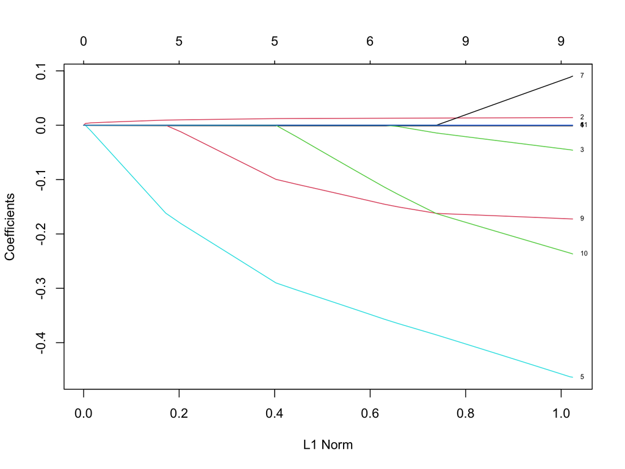

```r
plot(lasso.fit, label = TRUE)
```

The estimated coefficients for specific $\lambda$ values can be obtained using `coef()`.

```r
coef(lasso.fit, s = 0.06) # s:=\lambda
```

```
#> 11 x 1 sparse Matrix of class "dgCMatrix"
#>                         1
#> ...1        -5.190516e-04
#> age          5.397677e-03
#> sexF         .
#> sexM         .
#> trtgivenCMT -3.780294e-02
#> trtgivenRT   1.733176e-15
#> medwidsiL    .
#> medwidsiN    .
#> medwidsiS    .
#> extranodN    .
#> extranodY    .
```

One can also employ k-fold cross-validation to select the optimal value of $\lambda$. Below, we show how to do that using 10 folds and Harrel’s concordance index; however, one can also employ a deviance loss measure. Note, however, that none of these metrics account for competing events.

```r
set.seed(1)
lassoCV.fit <- cv.glmnet(x = x,
                         y = Surv(hd_train$time, hd_train$status == 1),
                         family = "cox",
                         alpha = 1,              # this determines lasso fit
                         nfolds = 10,
                         type.measure = "C")     # uses Harrel's C-index
```

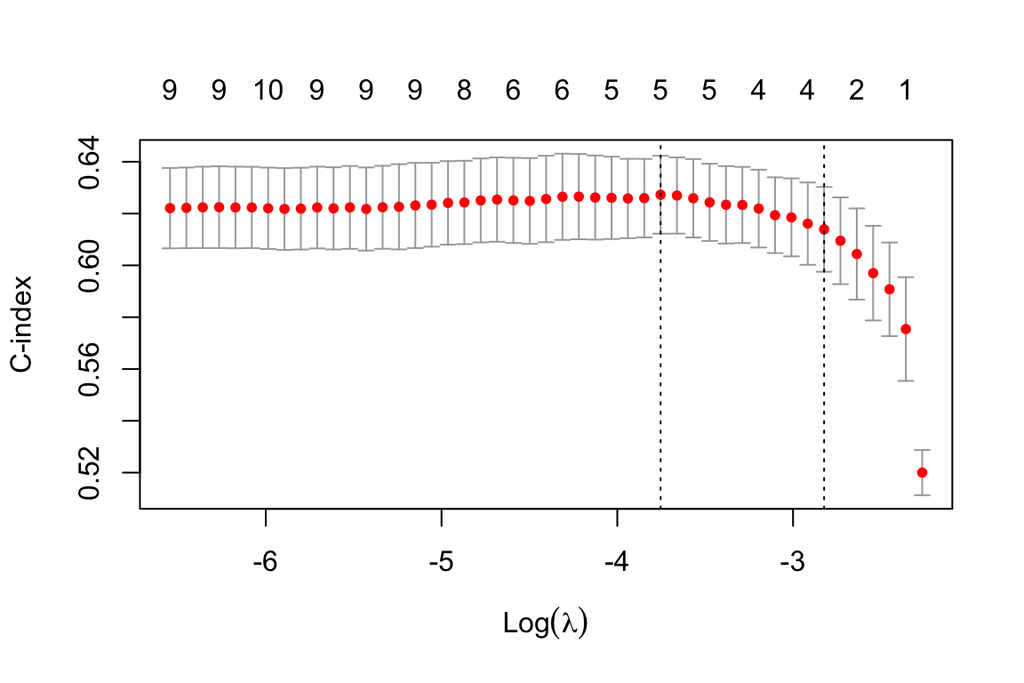

```r
plot(lassoCV.fit)
```

The specific $\lambda$ values marked with the left and right vertical lines in the plot shown above, can be obtained with the following commands.

```r
lassoCV.fit$lambda.min; lassoCV.fit$lambda.1se
```

```
#> [1] 0.02343168
#> [1] 0.05940785
```

The estimated coefficients for $\lambda=$ 0.0594078 are shown below, where we see that lasso selects age and treatment.

```r
coef(lassoCV.fit, s = lassoCV.fit$lambda.1se)
```

```
#> 11 x 1 sparse Matrix of class "dgCMatrix"
#>                         1
#> ...1        -5.251431e-04
#> age          5.508961e-03
#> sexF         .
#> sexM         .
#> trtgivenCMT -4.089011e-02
#> trtgivenRT   1.899413e-15
#> medwidsiL    .
#> medwidsiN    .
#> medwidsiS    .
#> extranodN    .
#> extranodY    .
```

## Cox model-based boosting - The `mboost` package

As before, for illustration purposes, we only fit the model associated to the first event type.

The output of the model indicates the estimated regression coefficients from which the estimated HR can be computed

```r
require(mboost)

csh_mboost <- glmboost(Surv(time, status == 1) ~ age +
                         sex +
                         trtgiven +
                         medwidsi +
                         extranod +
                         clinstg,
                       data = hd,
                       family = CoxPH(),
                       control = boost_control(mstop = 900,
                                               nu = 0.3,
                                               trace = FALSE),
                       center = FALSE)

print(csh_mboost)
```

```
#>
#>   Generalized Linear Models Fitted via Gradient Boosting
#>
#> Call:
#> glmboost.formula(formula = Surv(time, status == 1) ~ age + sex +     trtgiven + medwidsi + extranod + clinstg, data = hd, family = CoxPH(),     center = FALSE, control = boost_control(mstop = 900, nu = 0.3,         trace = FALSE))
#>
#>
#>   Cox Partial Likelihood
#>
#> Loss function:
#>
#> Number of boosting iterations: mstop = 900
#> Step size:  0.3
#> Offset:  0
#>
#> Coefficients:
#>         age        sexM  trtgivenRT   medwidsiN   medwidsiS   extranodY
#>  0.01497159  0.03194228  0.67363265 -0.05801666 -0.36732603  0.29942487
#>    clinstg2
#>  0.40659267
#> attr(,"offset")
#> [1] 0
```

```r
knitr::kable(round(exp(coef(csh_mboost, off2int = TRUE)), 4),
             col.names = c("HR"))
```

|  | HR |
| --- | --- |
| age | 1.0151 |
| sexM | 1.0325 |
| trtgivenRT | 1.9613 |
| medwidsiN | 0.9436 |
| medwidsiS | 0.6926 |
| extranodY | 1.3491 |
| clinstg2 | 1.5017 |

A plot of the coefficients across boosting iterations is shown:

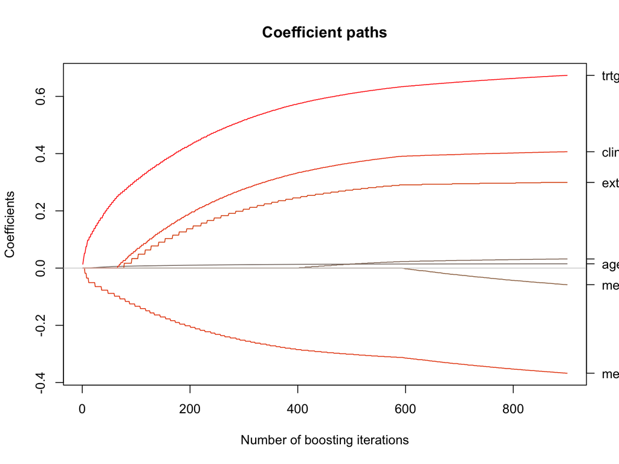

```r
plot(csh_mboost, main = "Coefficient paths", ylim = range(coef(csh_mboost)))
```

To do variable selection one can use the `varimp()` function. In the plot below we observe that age, treatment given, clinical stage and size of mediastinum involvement appear to be relevant.

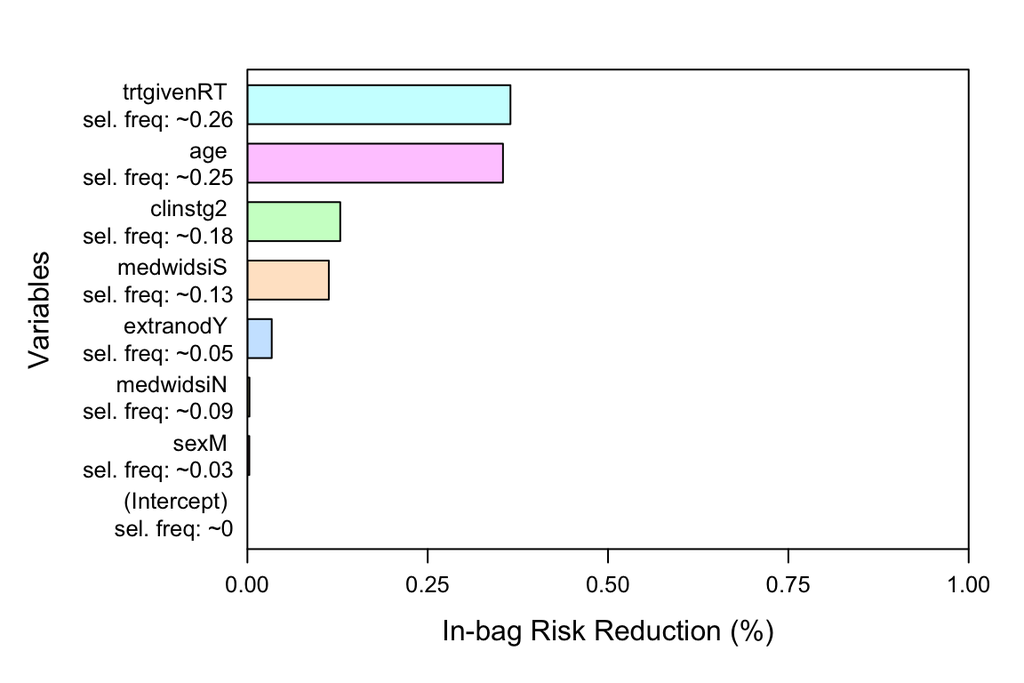

```r
plot(varimp(csh_mboost))
```

`mboost` permits cross-validation for hyper-parameter selection; specifically, the number of boosting iterations. Here, we show how to do this using 25 bootstrap samples (default). Estimation is done sequentially:

```r
set.seed(1)
cv.boost <- cvrisk(csh_mboost, papply = lapply)
```

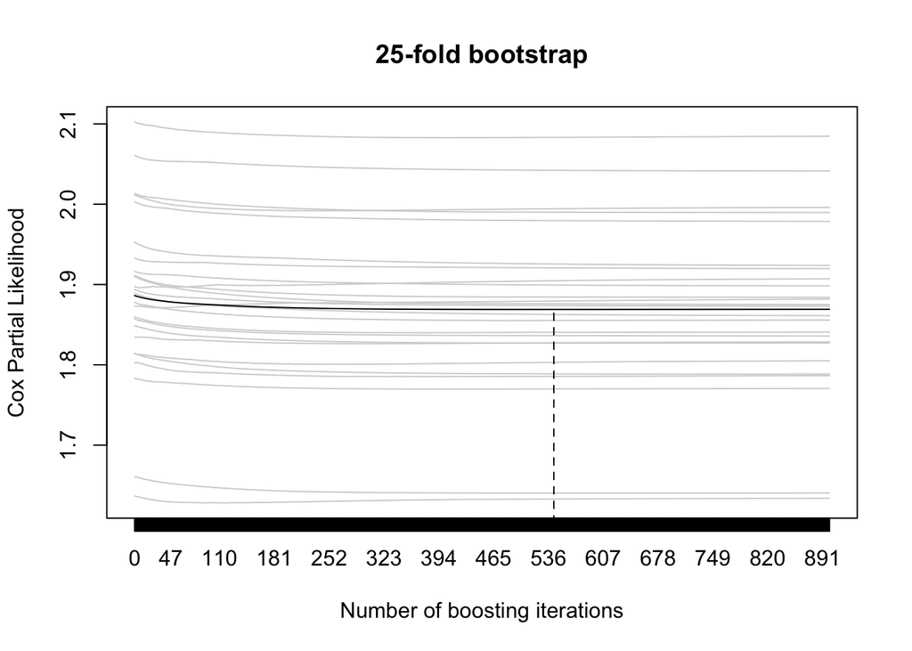

```r
plot(cv.boost)
```

```r
stop.B <- mstop(cv.boost)  # can serve to obtain optimal stopping parameter
stop.B
```

```
#> [1] 543
```

The above output shows that 543 boosting iterations is enough. Once the number is obtained one can use `glmboost()` with the resulting number of boosting iterations.

# References

Austin, Peter C., Douglas S. Lee, and Jason P. Fine. 2016. “Introduction to the Analysis of Survival Data in the Presence of Competing Risks.” *Circulation* 133 (6): 601–9. https://doi.org/10.1161/CIRCULATIONAHA.115.017719.

Harrell, Frank E. 2017. “Regression Modeling Strategies.” *Bios* 330 (2018): 14.